# Simulating fluctuations in estimated CFR with sample size

Thibaut Jombart

2021-11-18

# Proof of concept

Simulating the outcomes of cases using a known case fatality ratio (CFR) using **R** is easy. This process is by definition a Binomial draw, which is implemented by the function `rbinom`. See `?rbinom` for details of how this function works. The arguments of the function are simple:

```r
args(rbinom)
## function (n, size, prob)
## NULL
```

- `n` is the number of times we want to draw from the Binomial distribution
- `prob` is the probability, here, of death
- `size` is the size of the sample, here, the number of cases

So that if we want to simulate the number of death amongst 12 cases, with a CFR of 40%, we would then use something like:

```r
# set the random seed
set.seed(1)

# do the 'experiment' once
rbinom(n = 1, size = 12, prob = 0.4)
```

```
## [1] 4
```

```r
# repeat that 'sampling' 20 times
rbinom(n = 20, size = 12, prob = 0.4)
```

```
##  [1] 4 5 7 3 7 8 5 5 2 3 3 6 4 6 5 6 9 4 6 7
```

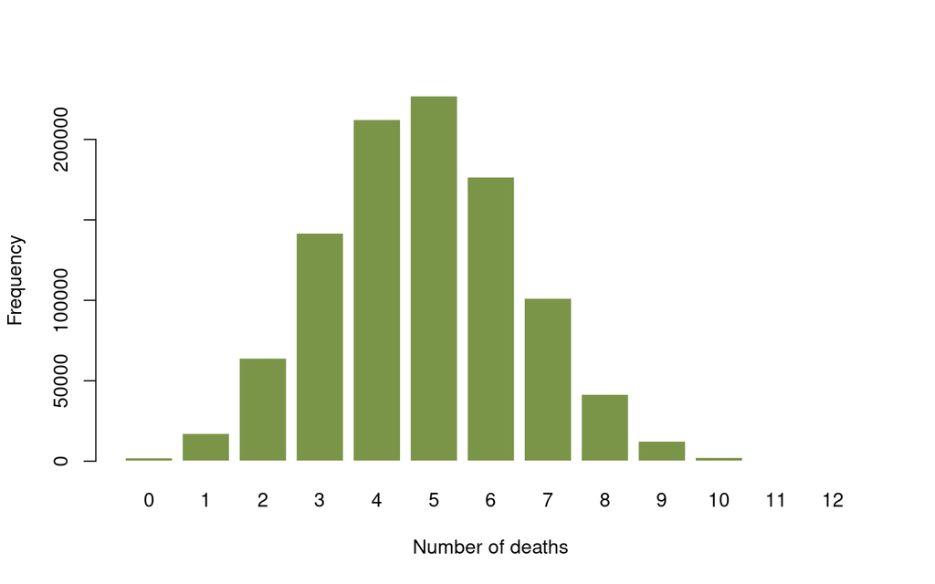

```r
# do it 1 million times, and examine the resulting distribution
x <- rbinom(n = 1e6, size = 12, prob = 0.4)
barplot(table(x),
        col = "#7A9548",
        border = "white",
        xlab = "Number of deaths",
        ylab = "Frequency")
```

# Making our own function

The following function wraps up the principle above, with the added tweaks:

- arguments have a clearer epidemiological meaning
- the output reports the number of cases, the number of deaths, survivors, and the associated ratio

```r
# Define the new function

simulate_outcome <- function(n = 1,
                             n_cases,
                             cfr) {
  ## simulate outcomes using binomial sampling
  res <- rbinom(n = n,
                prob = cfr,
                size = n_cases)

  ## shape final data.frame
  ### note: as the last object is returned, we do not need to assign the created
  ### data.frame to any object
  data.frame(cases = n_cases,
             deaths = res,
             survivors = n_cases - res,
             ratio = res / n_cases)
}


# try it
simulate_outcome(1, 100, 0.2)
```

```
##   cases deaths survivors ratio
## 1   100     22        78  0.22
```

```r
simulate_outcome(10, 60, 0.33)
```

```
##    cases deaths survivors     ratio
## 1     60     25        35 0.4166667
## 2     60     17        43 0.2833333
## 3     60     22        38 0.3666667
## 4     60     19        41 0.3166667
## 5     60     18        42 0.3000000
## 6     60     15        45 0.2500000
## 7     60     20        40 0.3333333
## 8     60     24        36 0.4000000
## 9     60     26        34 0.4333333
## 10    60     17        43 0.2833333
```

# Simulating estimated CFR over time

To show how sample size affects the estimation of CFR, we contrast the following situations, all assuming a true CFR of 20% over a period of 90 days:

- 5 daily cases
- 10 daily cases
- 100 daily cases

*dplyr* and *ggplot2* will be used to reorganise and display the results

```r
library(tidyverse)
# run simulations
sim_5_cases <- simulate_outcome(90, n_cases = 5, cfr = 0.2)
sim_10_cases <- simulate_outcome(90, n_cases = 10, cfr = 0.2)
sim_100_cases <- simulate_outcome(90, n_cases = 100, cfr = 0.2)

# bind them into a single data.frame
sims <- bind_rows(sim_5_cases, sim_10_cases, sim_100_cases) %>%
  mutate(cases = factor(cases)) %>%
  group_by(cases) %>%
  mutate(day = 1:n()) %>% # add 'day' variable
  select(day, everything()) # reorder data to have day first
glimpse(sims)
```

```
## Rows: 270
## Columns: 5
## Groups: cases [3]
## $ day       <int> 1, 2, 3, 4, 5, 6, 7, 8, 9, 10, 11, 12, 13, 14, 15, 16, 17, 1…
## $ cases     <fct> 5, 5, 5, 5, 5, 5, 5, 5, 5, 5, 5, 5, 5, 5, 5, 5, 5, 5, 5, 5, …
## $ deaths    <int> 1, 3, 1, 0, 0, 0, 1, 2, 1, 0, 0, 1, 2, 1, 1, 3, 1, 0, 2, 2, …
## $ survivors <dbl> 4, 2, 4, 5, 5, 5, 4, 3, 4, 5, 5, 4, 3, 4, 4, 2, 4, 5, 3, 3, …
## $ ratio     <dbl> 0.2, 0.6, 0.2, 0.0, 0.0, 0.0, 0.2, 0.4, 0.2, 0.0, 0.0, 0.2, …
```

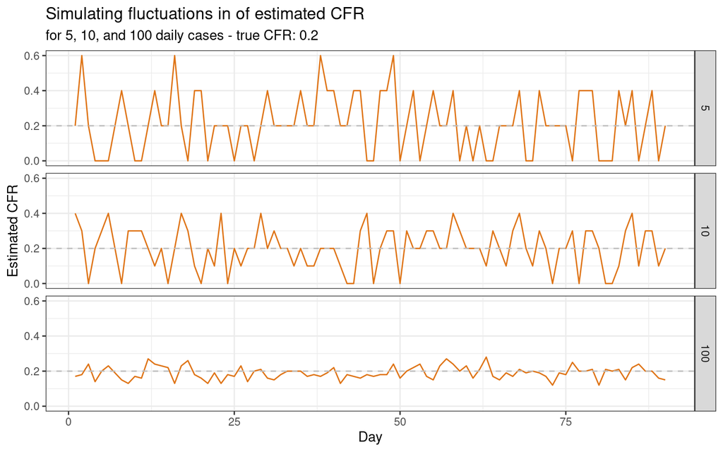

```r
# plot results
ggplot(sims, aes(x = day, y = ratio)) +
  theme_bw() +
  geom_line(color = "#DF7416") +
  facet_grid(cases ~ .) +
  geom_hline(yintercept = 0.2, color = "grey", linetype = 2) +
  labs(title = "Simulating fluctuations in of estimated CFR",
       x = "Day", y = "Estimated CFR",
       subtitle = "for 5, 10, and 100 daily cases - true CFR: 0.2")
```